# Testing TASI Index Normality Assumption

Thamir K. AlHashemi

January 1, 2016

In this post, I explore the **normality assumption** of the Saudi stock market; i.e. Tadawul. Mainly, I attempt to answer the question, “Is it valid to assume that Tadawul shows characteristics of normality in its returns?” The short answer is a resounding NO. Why? Continue reading.

Normality assumption is a choice made by financial analysts and risk managers to simplify their understanding of the financial markets.

Normality assumption implies that each stock/portfolio return is an independent realization from the same normal distribution; i.e. returns are i.i.d normal. It also implies that the returns distribution can be completely characterized by only two parameters: the mean and the variance. The skewness and (excess) kurtosis should be zero. However, this is rarely the case in financial markets.

Now let us consider the daily returns of TASI index for the period from 7-Jan-2007 to 27-Dec-2015 (illustrated and described below). Notice the extreme volatility in 2008.

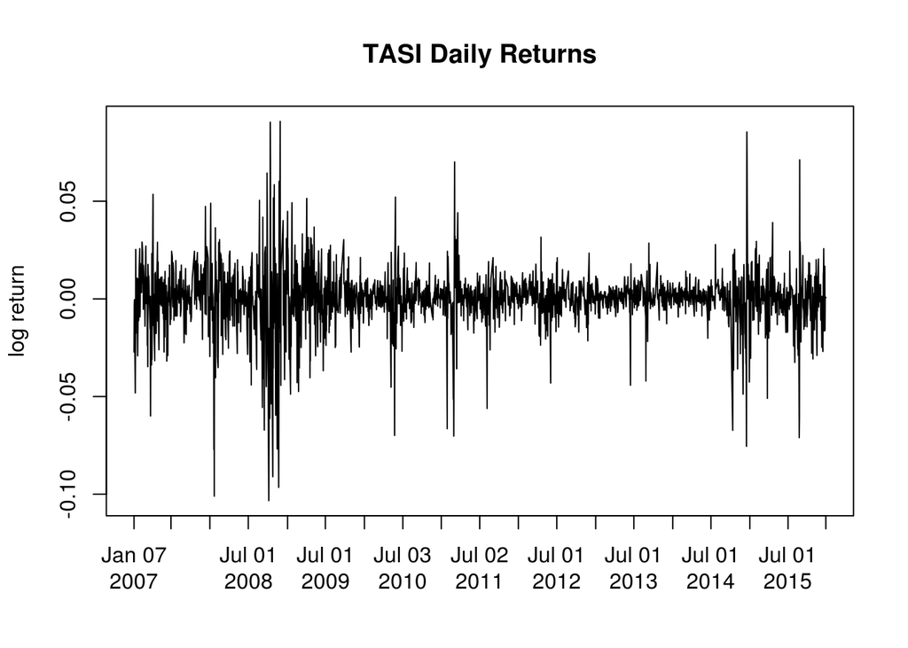

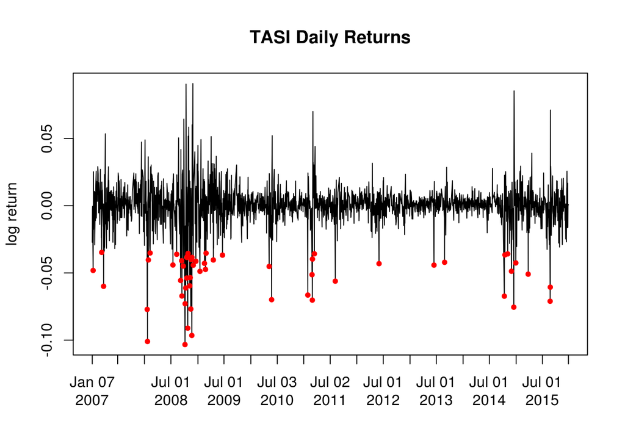

Conclusion: this analysis demonstrated that *TASI violates the assumption of normality.*

Thank you.